# Logistic Regression, Stochastic Gradient Descent and Support Vector Machine

### 2. Undersampling_1

First, we undersample by adjusting all class sizes to be equal to the smallest class.  
Original data: DEF:7362, FWD:4588, MID:4292, GK:2036  
The dataset is reduced from 18,278 records to 8,144 with each class containing 2,036 records.  
This approach is likely not desirable, since we lost over half of our data.

```
Total Records 8144
Total Classes: 4
Class Gini Index 0.75
Smallest Class Id: [1] Records: 2036
Largest Class Id: [1] Records: 2036
Accuracy when Guessing: 25.0 %
```

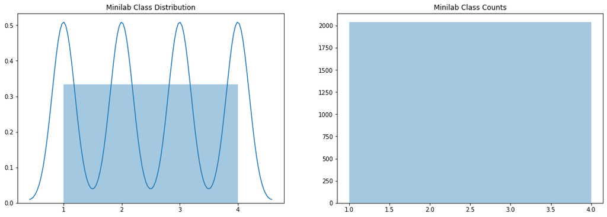

```python
from imblearn.under_sampling import RandomUnderSampler
import seaborn as sns

# Undersample the dataset using the RandomUnderSampler
# Set all class sizes equal to the smallest class.
us = RandomUnderSampler()

X_us, y_us = us.fit_sample(X_players_scaled, players_y)

y_us_new = y_us.copy()
y_us_new = pd.DataFrame(y_us_new)
y_us_new.columns = ['label']

dict = {'DEF':1, 'FWD':2, 'MID':3, 'GK':4}
y_us_new['label'] = y_us_new['label'].map(dict)
y_us_new1 = y_us_new.values.tolist()

# Plot the new class distributions for y using the same funnction as above.
def plot_class_dist_1(players_y):
    fig, axarr = plt.subplots(1, 2, figsize=(18, 6))
    class_ct = len(np.unique(players_y))
    vc = pd.value_counts(players_y)
    print('Total Records', len(players_y))
    print('Total Classes:', class_ct)
    print('Class Gini Index', gini_index(players_y))
    print('Smallest Class Id:',vc.idxmin(),'Records:',vc.min())
    print('Largest Class Id:',vc.idxmax(),'Records:',vc.max())
    print('Accuracy when Guessing:', np.round( (1 / len(np.unique(players_y))) * 100, 2), '%')

    sns.distplot(players_y, ax=axarr[0], bins=class_ct).set_title('Minilab Class Distribution');
    sns.distplot(players_y, ax=axarr[1], kde=False, bins=class_ct).set_title('Minilab Class Counts');

plot_class_dist_1(y_us_new1)
```

```
Best parameters set found on development set:

{'C': 1, 'class_weight': {'DEF': 0.2, 'FWD': 0.2, 'GK': 0.1, 'MID': 0.3}, 'max_iter': 800, 'multi_class': 'multinomial', 'penalty': 'l2', 'solver': 'lbfgs'}

Grid scores on development set:

0.85157 (+/-0.032) for {'C': 0.1, 'class_weight': None, 'max_iter': 800, 'multi_class': 'multinomial', 'penalty': 'l2', 'solver': 'lbfgs'}
0.85157 (+/-0.032) for {'C': 0.1, 'class_weight': 'balanced', 'max_iter': 800, 'multi_class': 'multinomial', 'penalty': 'l2', 'solver': 'lbfgs'}
0.84927 (+/-0.026) for {'C': 0.1, 'class_weight': {'DEF': 0.2, 'FWD': 0.2, 'GK': 0.1, 'MID': 0.3}, 'max_iter': 800, 'multi_class': 'multinomial', 'penalty': 'l2', 'solver': 'lbfgs'}
0.85188 (+/-0.033) for {'C': 1, 'class_weight': None, 'max_iter': 800, 'multi_class': 'multinomial', 'penalty': 'l2', 'solver': 'lbfgs'}
0.85188 (+/-0.033) for {'C': 1, 'class_weight': 'balanced', 'max_iter': 800, 'multi_class': 'multinomial', 'penalty': 'l2', 'solver': 'lbfgs'}
0.85618 (+/-0.029) for {'C': 1, 'class_weight': {'DEF': 0.2, 'FWD': 0.2, 'GK': 0.1, 'MID': 0.3}, 'max_iter': 800, 'multi_class': 'multinomial', 'penalty': 'l2', 'solver': 'lbfgs'}

Detailed classification report:

The model is trained on the full development set.
The scores are computed on the full evaluation set.

              precision    recall  f1-score   support

         DEF       0.92      0.90      0.91       408
         FWD       0.87      0.69      0.77       407
          GK       1.00      1.00      1.00       407
         MID       0.67      0.83      0.74       407

    accuracy                           0.85      1629
   macro avg       0.86      0.85      0.85      1629
weighted avg       0.86      0.85      0.85      1629


CPU times: user 1min 46s, sys: 1.02 s, total: 1min 47s
Wall time: 18.1 s
```

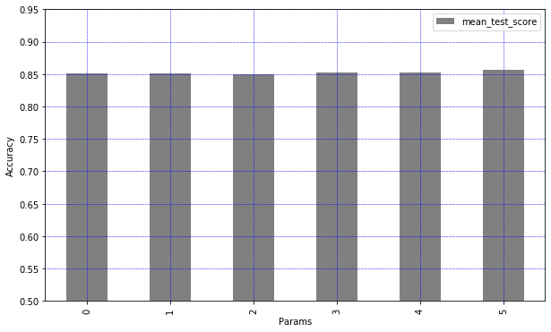

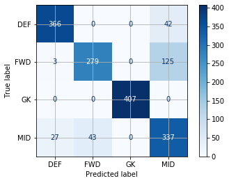

```python
cv_object = StratifiedShuffleSplit(n_splits=1, test_size=0.2, random_state=0)
train_index_us, test_index_us = next(cv_object.split(X_us, y_us))
X_us_train = X_us[train_index_us]
y_us_train = y_us[train_index_us]
X_us_test = X_us[test_index_us]
y_us_test = y_us[test_index_us]

# Logistic Regression
params = [
      {'C': [.1,1], 'class_weight': [None,'balanced',{
                                "DEF": 0.2,"FWD": 0.2,"GK": 0.1,"MID": 0.3
                            },], 'solver': ['lbfgs'],
       'penalty': ['l2'],'multi_class':['multinomial'], 'max_iter':[800]
     }]
clf = LogisticRegression()
%time m = evaluate_model_performance('LR Undersmpl-1',params,clf,X_us_train, y_us_train, X_us_test, y_us_test,numCVs)
model_stats = model_stats.append(m)
```

### 3. Undersampling_2

Next, we undersample by adjusting all class sizes to be equal to that of MID, see whether we can improve its f1 score.  
Original data: DEF:7362, FWD:4588, MID:4292, GK:2036  
The dataset is reduced from 18,278 records to 14,912 with the first three classes each containing 4,292 records and 'GK' still 2,036 records.

```
Total Records 14912
Total Classes: 4
Class Gini Index 0.7328340570833871
Smallest Class Id: [4] Records: 2036
Largest Class Id: [1] Records: 4292
Accuracy when Guessing: 25.0 %
```

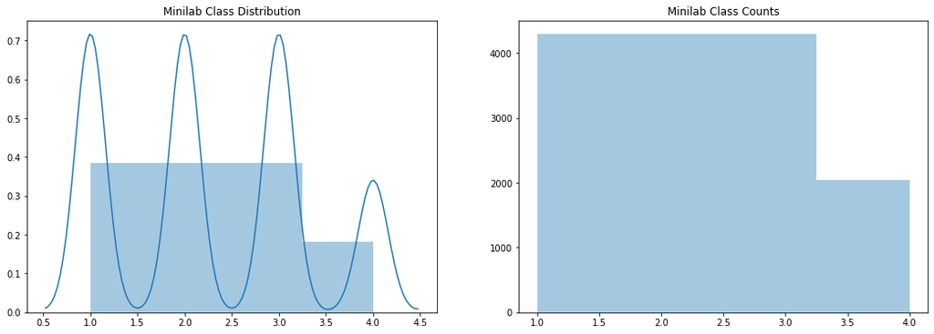

```python
from imblearn.under_sampling import RandomUnderSampler
import seaborn as sns
y = players_y
# Undersample the dataset using the RandomUnderSampler
# Set all class sizes equal to the smallest class.
ori_dict = {'DEF':4292, 'FWD':4292, 'MID':4292, 'GK':2036}
us_dict = RandomUnderSampler(sampling_strategy=ori_dict)
X_us_dict, y_us_dict = us_dict.fit_sample(X_players_scaled, y)

y_us_d = y_us_dict.copy()
y_us_d = pd.DataFrame(y_us_d)
y_us_d.columns = ['label']

dict = {'DEF':1, 'FWD':2, 'MID':3, 'GK':4}
y_us_d['label'] = y_us_d['label'].map(dict)
y_us_d1 = y_us_d.values.tolist()

# Plot the new class distributions for y using the same funnction as above.
def plot_class_dist_1(y):
    fig, axarr = plt.subplots(1, 2, figsize=(18, 6))
    class_ct = len(np.unique(y))
    vc = pd.value_counts(y)
    print('Total Records', len(y))
    print('Total Classes:', class_ct)
    print('Class Gini Index', gini_index(y))
    print('Smallest Class Id:',vc.idxmin(),'Records:',vc.min())
    print('Largest Class Id:',vc.idxmax(),'Records:',vc.max())
    print('Accuracy when Guessing:', np.round( (1 / len(np.unique(y))) * 100, 2), '%')

    sns.distplot(y, ax=axarr[0], bins=class_ct).set_title('Minilab Class Distribution');
    sns.distplot(y, ax=axarr[1], kde=False, bins=class_ct).set_title('Minilab Class Counts');

plot_class_dist_1(y_us_d1)
```

```
Best parameters set found on development set:

{'C': 1, 'class_weight': 'balanced', 'max_iter': 800, 'multi_class': 'multinomial', 'penalty': 'l2', 'solver': 'lbfgs'}

Grid scores on development set:

0.83679 (+/-0.014) for {'C': 0.1, 'class_weight': None, 'max_iter': 800, 'multi_class': 'multinomial', 'penalty': 'l2', 'solver': 'lbfgs'}
0.83687 (+/-0.013) for {'C': 0.1, 'class_weight': 'balanced', 'max_iter': 800, 'multi_class': 'multinomial', 'penalty': 'l2', 'solver': 'lbfgs'}
0.83804 (+/-0.013) for {'C': 1, 'class_weight': None, 'max_iter': 800, 'multi_class': 'multinomial', 'penalty': 'l2', 'solver': 'lbfgs'}
0.83821 (+/-0.013) for {'C': 1, 'class_weight': 'balanced', 'max_iter': 800, 'multi_class': 'multinomial', 'penalty': 'l2', 'solver': 'lbfgs'}

Detailed classification report:

The model is trained on the full development set.
The scores are computed on the full evaluation set.

              precision    recall  f1-score   support

         DEF       0.91      0.92      0.92       859
         FWD       0.81      0.77      0.79       859
          GK       1.00      1.00      1.00       407
         MID       0.71      0.73      0.72       858

    accuracy                           0.83      2983
   macro avg       0.86      0.86      0.86      2983
weighted avg       0.84      0.83      0.83      2983


CPU times: user 2min 42s, sys: 1.44 s, total: 2min 43s
Wall time: 27.5 s
```

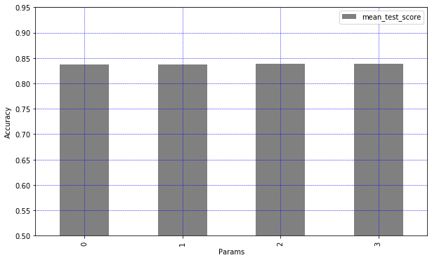

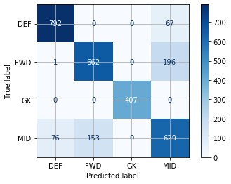

```python
cv_object = StratifiedShuffleSplit(n_splits=1, test_size=0.2, random_state=0)
train_index_us, test_index_us = next(cv_object.split(X_us_dict, y_us_dict))
X_us_dict_train = X_us_dict[train_index_us]
y_us_dict_train = y_us_dict[train_index_us]
X_us_dict_test = X_us_dict[test_index_us]
y_us_dict_test = y_us_dict[test_index_us]

# Logistic Regression
params = [{
          'C': [.1,1],
          'class_weight': [None,'balanced'],
          'solver': ['lbfgs'],
          'penalty': ['l2'],
          'multi_class':['multinomial'],
          'max_iter':[800]
     }]
clf = LogisticRegression()
%time m = evaluate_model_performance('LR Undersampl-2', params,clf,X_us_dict_train, y_us_dict_train, X_us_dict_test, y_us_dict_test,numCVs)
model_stats = model_stats.append(m)
```

### 4. SMOTE: Synthetic Minority Over-sampling

SMOTE works by selecting examples that are close in the feature space, drawing a line between the examples in the feature space and drawing a new sample at a point along that line. Specifically, a random example from the minority class is first chosen. Then k of the nearest neighbors for that example are found (typically k=5). A randomly selected neighbor is chosen and a synthetic example is created at a randomly selected point between the two examples in feature space.  
şş https://machinelearningmastery.com/smote-oversampling-for-imbalanced-classification/

We use Synthetic Minority Over-sampling to over sample all classes, except the majority.  
Original data: DEF:7362, FWD:4588, MID:4292, GK:2036  
The dataset is increased from 18,278 records to 29,448 with each class containing 7,362 records.

```
Total Records 29448
Total Classes: 4
Class Gini Index 0.75
Smallest Class Id: [2] Records: 7362
Largest Class Id: [2] Records: 7362
Accuracy when Guessing: 25.0 %
```

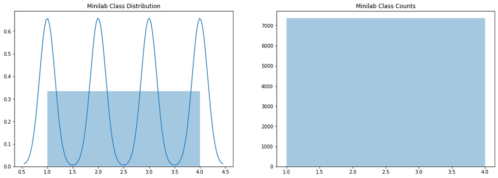

```python
from imblearn.over_sampling import SMOTE

# Oversample using SMOTE
# Make all classes the same size as the majority class.
# WARNING - This can exponentially increase the size of the input dataset.
sm = SMOTE(sampling_strategy='not majority')
X_sm, y_sm = sm.fit_sample(X_players_scaled, y)

y_sm_new = y_sm.copy()
y_sm_new = pd.DataFrame(y_sm_new)
y_sm_new.columns = ['label']

dict = {'DEF':1, 'FWD':2, 'MID':3, 'GK':4}
y_sm_new['label'] = y_sm_new['label'].map(dict)
y_sm_new1 = y_sm_new.values.tolist()

plot_class_dist_1(y_sm_new1)
```

```
Best parameters set found on development set:

{'C': 1, 'class_weight': None, 'max_iter': 800, 'multi_class': 'multinomial', 'penalty': 'l2', 'solver': 'lbfgs'}

Grid scores on development set:

0.86255 (+/-0.010) for {'C': 0.1, 'class_weight': None, 'max_iter': 800, 'multi_class': 'multinomial', 'penalty': 'l2', 'solver': 'lbfgs'}
0.86255 (+/-0.010) for {'C': 0.1, 'class_weight': 'balanced', 'max_iter': 800, 'multi_class': 'multinomial', 'penalty': 'l2', 'solver': 'lbfgs'}
0.86387 (+/-0.009) for {'C': 1, 'class_weight': None, 'max_iter': 800, 'multi_class': 'multinomial', 'penalty': 'l2', 'solver': 'lbfgs'}
0.86383 (+/-0.009) for {'C': 1, 'class_weight': 'balanced', 'max_iter': 800, 'multi_class': 'multinomial', 'penalty': 'l2', 'solver': 'lbfgs'}

Detailed classification report:

The model is trained on the full development set.
The scores are computed on the full evaluation set.

              precision    recall  f1-score   support

         DEF       0.93      0.92      0.93      1473
         FWD       0.81      0.80      0.80      1473
          GK       1.00      1.00      1.00      1472
         MID       0.73      0.75      0.74      1472

    accuracy                           0.87      5890
   macro avg       0.87      0.87      0.87      5890
weighted avg       0.87      0.87      0.87      5890


CPU times: user 5min 47s, sys: 2.68 s, total: 5min 49s
Wall time: 58.7 s
```

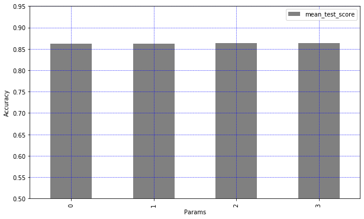

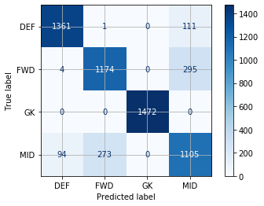

```python
cv_object = StratifiedShuffleSplit(n_splits=1, test_size=0.2, random_state=0)
train_index_us, test_index_us = next(cv_object.split(X_sm, y_sm))
X_sm_train = X_sm[train_index_us]
y_sm_train = y_sm[train_index_us]
X_sm_test = X_sm[test_index_us]
y_sm_test = y_sm[test_index_us]

# Logistic Regression
params = [{
          'C': [.1,1],
          'class_weight': [None,'balanced'],
          'solver': ['lbfgs'],
          'penalty': ['l2'],
          'multi_class':['multinomial'],
          'max_iter':[800]
     }]
clf = LogisticRegression()
%time m = evaluate_model_performance('LR SMOTE', params,clf,X_sm_train, y_sm_train, X_sm_test, y_sm_test,numCVs)
model_stats = model_stats.append(m)
```

### 5. LR using PCA

We now use Principal Component Analysis (PCA) to perform the LR analysis. PCA is an unsupervised linear transformation technique for dimensionality reduction. It is a useful technique when we have a large number of correlated features in the dataset. It allows us to summarize the information with a smaller number of collectively representative variables.

```python
from sklearn.decomposition import PCA
import matplotlib.pyplot as plt

def plot_pca(X):
    # Perform PCA on the data to reduce the number of initial features
    # and to remove correlations that are common between pixel features
    pca = PCA(n_components=X.shape[1])
    pca.fit(X)

    # Inspect the explained variances to determine how many components to use
    plt.subplots(figsize=(8, 8))
    plt.plot(np.cumsum(pca.explained_variance_ratio_))
    plt.xlabel('number of components')
    plt.ylabel('cumulative explained variance');
    print('Cumulative Explained variance at 200 components:',sum(pca.explained_variance_ratio_[0:199]) )
```

```
Cumulative Explained variance at 200 components: 1.0000000000000004
```

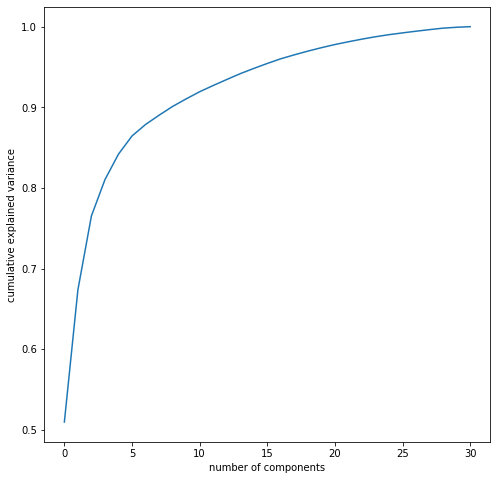

```python
plot_pca(X_players_scaled)
```

The plot above shows us that 10 PCA's would account for about 90% of the models variations.  
We will use the model_stats data frame to store each model's best param stat to compare them.

```
Best parameters set found on development set:

{'C': 1, 'class_weight': None, 'max_iter': 800, 'multi_class': 'multinomial', 'penalty': 'l2', 'solver': 'lbfgs'}

Grid scores on development set:

0.83689 (+/-0.012) for {'C': 0.1, 'class_weight': None, 'max_iter': 800, 'multi_class': 'multinomial', 'penalty': 'l2', 'solver': 'lbfgs'}
0.83689 (+/-0.012) for {'C': 0.1, 'class_weight': None, 'max_iter': 800, 'multi_class': 'multinomial', 'penalty': 'l2', 'solver': 'newton-cg'}
0.83443 (+/-0.010) for {'C': 0.1, 'class_weight': 'balanced', 'max_iter': 800, 'multi_class': 'multinomial', 'penalty': 'l2', 'solver': 'lbfgs'}
0.83443 (+/-0.010) for {'C': 0.1, 'class_weight': 'balanced', 'max_iter': 800, 'multi_class': 'multinomial', 'penalty': 'l2', 'solver': 'newton-cg'}
0.83737 (+/-0.013) for {'C': 1, 'class_weight': None, 'max_iter': 800, 'multi_class': 'multinomial', 'penalty': 'l2', 'solver': 'lbfgs'}
0.83730 (+/-0.013) for {'C': 1, 'class_weight': None, 'max_iter': 800, 'multi_class': 'multinomial', 'penalty': 'l2', 'solver': 'newton-cg'}
0.83552 (+/-0.011) for {'C': 1, 'class_weight': 'balanced', 'max_iter': 800, 'multi_class': 'multinomial', 'penalty': 'l2', 'solver': 'lbfgs'}
0.83552 (+/-0.011) for {'C': 1, 'class_weight': 'balanced', 'max_iter': 800, 'multi_class': 'multinomial', 'penalty': 'l2', 'solver': 'newton-cg'}

Detailed classification report:

The model is trained on the full development set.
The scores are computed on the full evaluation set.

              precision    recall  f1-score   support

         DEF       0.92      0.95      0.93      1473
         FWD       0.80      0.80      0.80       918
          GK       1.00      1.00      1.00       407
         MID       0.68      0.66      0.67       858

    accuracy                           0.85      3656
   macro avg       0.85      0.85      0.85      3656
weighted avg       0.84      0.85      0.85      3656


CPU times: user 4min 32s, sys: 2.04 s, total: 4min 34s
Wall time: 45.9 s
```

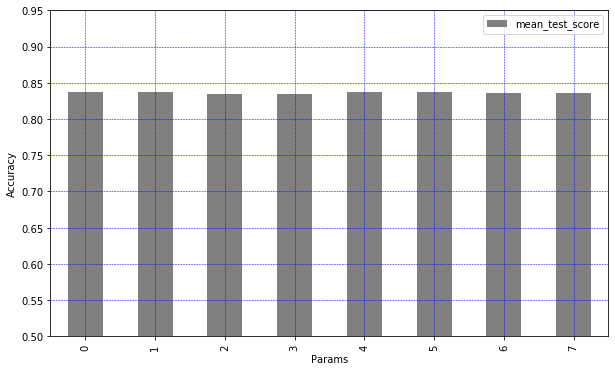

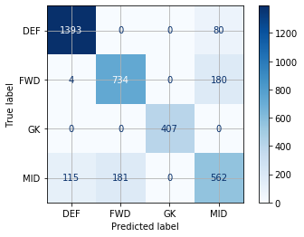

```python
#Analysing Logistic regression using PCA covering about 90% of variance which is about 10

pca = PCA(n_components=10)
X_pca = pca.fit(X_players_scaled).transform(X_players_scaled) # fit data and then transform it

params = [
      {'C': [.1,1], 'class_weight': [None,'balanced'], 'solver': ['lbfgs','newton-cg'],
       'penalty': ['l2'],'multi_class':['multinomial'], 'max_iter':[800]
     }]

clf = LogisticRegression()
%time m = evaluate_model_performance('LR PCA10',params,clf,X_pca[train_index], y_train, X_pca[test_index], y_test, numCVs)
# print the components
model_stats = model_stats.append(m)
```

### I.2. Stochastic Gradient Descent Classifier

Stochastic Gradient Descent (SGD) is a popular alternative to the batch gradient descent algorithm when we have a very large dataset that is not uncommon in many machine learning applications. It is an approximation of gradient descent but it can reach convergence much faster because of the more frequent weight updates and it also can be used in online learning. Although we have a mid sized dataset, we are running the SGD model just to evaluate its time performance in converging to the minimum.

```
Best parameters set found on development set:

{'alpha': 0.0001, 'class_weight': 'balanced', 'epsilon': 0.1, 'eta0': 0.0, 'fit_intercept': False, 'learning_rate': 'optimal', 'loss': 'hinge', 'max_iter': 800, 'penalty': 'l2'}

Grid scores on development set:

0.80728 (+/-0.015) for {'alpha': 0.0001, 'class_weight': None, 'epsilon': 0.1, 'eta0': 0.0, 'fit_intercept': False, 'learning_rate': 'optimal', 'loss': 'hinge', 'max_iter': 800, 'penalty': 'l2'}
0.80919 (+/-0.021) for {'alpha': 0.0001, 'class_weight': 'balanced', 'epsilon': 0.1, 'eta0': 0.0, 'fit_intercept': False, 'learning_rate': 'optimal', 'loss': 'hinge', 'max_iter': 800, 'penalty': 'l2'}
0.79743 (+/-0.026) for {'alpha': 0.0001, 'class_weight': {'DEF': 0.2, 'FWD': 0.2, 'GK': 0.1, 'MID': 0.3}, 'epsilon': 0.1, 'eta0': 0.0, 'fit_intercept': False, 'learning_rate': 'optimal', 'loss': 'hinge', 'max_iter': 800, 'penalty': 'l2'}
0.80235 (+/-0.022) for {'alpha': 1e-05, 'class_weight': None, 'epsilon': 0.1, 'eta0': 0.0, 'fit_intercept': False, 'learning_rate': 'optimal', 'loss': 'hinge', 'max_iter': 800, 'penalty': 'l2'}
0.80215 (+/-0.023) for {'alpha': 1e-05, 'class_weight': 'balanced', 'epsilon': 0.1, 'eta0': 0.0, 'fit_intercept': False, 'learning_rate': 'optimal', 'loss': 'hinge', 'max_iter': 800, 'penalty': 'l2'}
0.78033 (+/-0.045) for {'alpha': 1e-05, 'class_weight': {'DEF': 0.2, 'FWD': 0.2, 'GK': 0.1, 'MID': 0.3}, 'epsilon': 0.1, 'eta0': 0.0, 'fit_intercept': False, 'learning_rate': 'optimal', 'loss': 'hinge', 'max_iter': 800, 'penalty': 'l2'}

Detailed classification report:

The model is trained on the full development set.
The scores are computed on the full evaluation set.

              precision    recall  f1-score   support

         DEF       0.93      0.92      0.92      1473
         FWD       0.81      0.74      0.77       918
          GK       0.90      1.00      0.95       407
         MID       0.64      0.68      0.66       858

    accuracy                           0.82      3656
   macro avg       0.82      0.83      0.82      3656
weighted avg       0.83      0.82      0.83      3656


CPU times: user 1min 20s, sys: 310 ms, total: 1min 20s
Wall time: 23.8 s
```

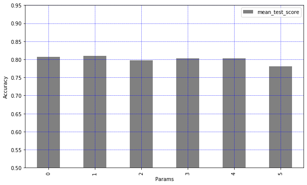

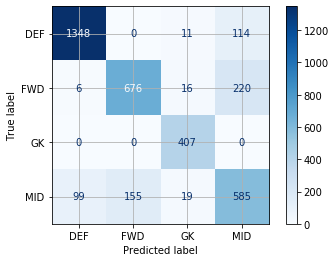

```python
#SGD classifier
from sklearn.linear_model import SGDClassifier
params = [
      {'loss': ['hinge'],'penalty': ['l2'],
       'alpha': [.0001,.00001], 'fit_intercept': [False],'epsilon': [0.1],
       'learning_rate': ['optimal'], 'eta0': [0.0],
       'class_weight': [None,'balanced',{
                                "DEF": 0.2,"FWD": 0.2,"GK": 0.1,"MID": 0.3  },], 'max_iter':[800]
     }]
#penalty='l2', C=1.0, class_weight=None, solver='liblinear'
#solver{‘newton-cg’, ‘lbfgs’, ‘liblinear’, ‘sag’, ‘saga’}, default=’lbfgs’
clf = SGDClassifier()
%time m = evaluate_model_performance('SGD', params,clf,X_train, y_train, X_test, y_test,numCVs)
model_stats = model_stats.append(m)
```

### I.3. Support Vector Machine

Another supervised learning model that is used in this minilab is the support vector machine (SVM) and can be considered an extension of the perceptron. We will now perform multiclass support vector analysis using various tuning perameters.  
SVM is a powerful machine learning technique which is capable of performing both linear, nonlinear classifications, regression and outlier detection. SVM's are good for small and medium size datsets.

### 1. SVC (Orignal data)

```
Best parameters set found on development set:

{'C': 75, 'class_weight': None, 'gamma': 0.01, 'kernel': 'rbf'}

Grid scores on development set:

0.85946 (+/-0.022) for {'C': 100, 'class_weight': None, 'gamma': 0.01, 'kernel': 'rbf'}
0.83710 (+/-0.016) for {'C': 100, 'class_weight': None, 'gamma': 0.05, 'kernel': 'rbf'}
0.85734 (+/-0.024) for {'C': 100, 'class_weight': 'balanced', 'gamma': 0.01, 'kernel': 'rbf'}
0.83757 (+/-0.014) for {'C': 100, 'class_weight': 'balanced', 'gamma': 0.05, 'kernel': 'rbf'}
0.85570 (+/-0.013) for {'C': 100, 'class_weight': {'DEF': 0.2, 'FWD': 0.2, 'GK': 0.1, 'MID': 0.3}, 'gamma': 0.01, 'kernel': 'rbf'}
0.84982 (+/-0.022) for {'C': 100, 'class_weight': {'DEF': 0.2, 'FWD': 0.2, 'GK': 0.1, 'MID': 0.3}, 'gamma': 0.05, 'kernel': 'rbf'}
0.86028 (+/-0.024) for {'C': 75, 'class_weight': None, 'gamma': 0.01, 'kernel': 'rbf'}
0.83956 (+/-0.014) for {'C': 75, 'class_weight': None, 'gamma': 0.05, 'kernel': 'rbf'}
0.85816 (+/-0.021) for {'C': 75, 'class_weight': 'balanced', 'gamma': 0.01, 'kernel': 'rbf'}
0.83983 (+/-0.015) for {'C': 75, 'class_weight': 'balanced', 'gamma': 0.05, 'kernel': 'rbf'}
0.85556 (+/-0.014) for {'C': 75, 'class_weight': {'DEF': 0.2, 'FWD': 0.2, 'GK': 0.1, 'MID': 0.3}, 'gamma': 0.01, 'kernel': 'rbf'}
0.85180 (+/-0.023) for {'C': 75, 'class_weight': {'DEF': 0.2, 'FWD': 0.2, 'GK': 0.1, 'MID': 0.3}, 'gamma': 0.05, 'kernel': 'rbf'}

Detailed classification report:

The model is trained on the full development set.
The scores are computed on the full evaluation set.

              precision    recall  f1-score   support

         DEF       0.93      0.94      0.94      1473
         FWD       0.82      0.82      0.82       918
          GK       1.00      1.00      1.00       407
         MID       0.71      0.69      0.70       858

    accuracy                           0.86      3656
   macro avg       0.86      0.86      0.86      3656
weighted avg       0.86      0.86      0.86      3656


CPU times: user 7min 38s, sys: 5.13 s, total: 7min 44s
Wall time: 7min 44s
```

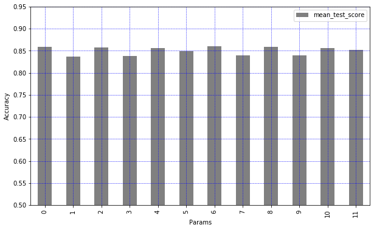

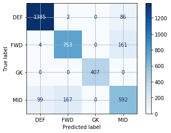

```python
#SVC 1
params = [
      {'C': [100,75], 'class_weight': [None,'balanced',{
                                "DEF": 0.2,"FWD": 0.2,"GK": 0.1,"MID": 0.3
                            },],'gamma': [.01,.05], 'kernel': ['rbf']},
     ]
clf = SVC()
%time m = evaluate_model_performance('SVC', params,clf,X_train, y_train, X_test, y_test, numCVs)
model_stats = model_stats.append(m)
```

### 2. SVC (SMOTE sampling)

Since SMOTE sampling performed real good in LR we will try this sampling stratergy using SVC.  
We reduced parameters and cv for model testing in the final paper as the SMOTE SVC takes a lot of procesing time.

```
Best parameters set found on development set:

{'C': 100, 'class_weight': None, 'gamma': 0.1, 'kernel': 'rbf'}

Grid scores on development set:

0.91421 (+/-0.004) for {'C': 100, 'class_weight': None, 'gamma': 0.1, 'kernel': 'rbf'}
0.90750 (+/-0.003) for {'C': 100, 'class_weight': None, 'gamma': 0.05, 'kernel': 'rbf'}

Detailed classification report:

The model is trained on the full development set.
The scores are computed on the full evaluation set.

              precision    recall  f1-score   support

         DEF       0.94      0.92      0.93      1473
         FWD       0.91      0.90      0.90      1473
          GK       1.00      1.00      1.00      1472
         MID       0.83      0.86      0.85      1472

    accuracy                           0.92      5890
   macro avg       0.92      0.92      0.92      5890
weighted avg       0.92      0.92      0.92      5890


CPU times: user 1min 32s, sys: 1.41 s, total: 1min 34s
Wall time: 1min 34s
```

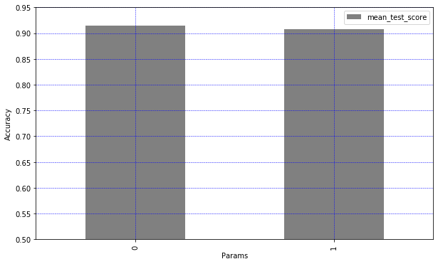

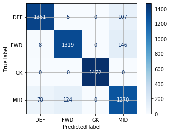

```python
#SVC SMOTE
params = [
      {'C': [100], 'class_weight': [None],'gamma': [.1,.05], 'kernel': ['rbf']},
     ]
clf = SVC()
%time m = evaluate_model_performance('SVC SMOTE', params,clf,X_sm_train, y_sm_train, X_sm_test, y_sm_test,5)
model_stats = model_stats.append(m)
```

## II. Model Advantage

```python
pd.set_option('display.expand_frame_repr', False)
#model_stats = model_stats.drop(['model_param'], axis=1)
display(Markdown(model_stats.to_markdown()))
```

|  | model_name | CM | time_refit | model_param | weighted_f1_score |
| --- | --- | --- | --- | --- | --- |
| 0 | LR Orignal | precision recall f1-score support | 0.512998 | {'C': 0.1, 'class_weight': None, 'max_iter': 800, 'multi_class': 'multinomial', 'penalty': 'l2', 'solver': 'lbfgs'} | 0.86 |
|  |  | DEF 0.93 0.94 0.94 1473 |  |  |  |
|  |  | FWD 0.81 0.81 0.81 918 |  |  |  |
|  |  | GK 1.00 1.00 1.00 407 |  |  |  |
|  |  | MID 0.70 0.69 0.70 858 |  |  |  |
|  |  | accuracy 0.86 3656 |  |  |  |
|  |  | macro avg 0.86 0.86 0.86 3656 |  |  |  |
|  |  | weighted avg 0.86 0.86 0.86 3656 |  |  |  |
| 0 | LR Undersmpl-1 | precision recall f1-score support | 0.481031 | {'C': 1, 'class_weight': {'DEF': 0.2, 'FWD': 0.2, 'GK': 0.1, 'MID': 0.3}, 'max_iter': 800, 'multi_class': 'multinomial', 'penalty': 'l2', 'solver': 'lbfgs'} | 0.85 |
|  |  | DEF 0.92 0.90 0.91 408 |  |  |  |
|  |  | FWD 0.87 0.69 0.77 407 |  |  |  |
|  |  | GK 1.00 1.00 1.00 407 |  |  |  |
|  |  | MID 0.67 0.83 0.74 407 |  |  |  |
|  |  | accuracy 0.85 1629 |  |  |  |
|  |  | macro avg 0.86 0.85 0.85 1629 |  |  |  |
|  |  | weighted avg 0.86 0.85 0.85 1629 |  |  |  |
| 0 | LR Undersampl-2 | precision recall f1-score support | 0.962561 | {'C': 1, 'class_weight': 'balanced', 'max_iter': 800, 'multi_class': 'multinomial', 'penalty': 'l2', 'solver': 'lbfgs'} | 0.83 |
|  |  | DEF 0.91 0.92 0.92 859 |  |  |  |
|  |  | FWD 0.81 0.77 0.79 859 |  |  |  |
|  |  | GK 1.00 1.00 1.00 407 |  |  |  |
|  |  | MID 0.71 0.73 0.72 858 |  |  |  |
|  |  | accuracy 0.83 2983 |  |  |  |
|  |  | macro avg 0.86 0.86 0.86 2983 |  |  |  |
|  |  | weighted avg 0.84 0.83 0.83 2983 |  |  |  |
| 0 | LR SMOTE | precision recall f1-score support | 1.46996 | {'C': 1, 'class_weight': None, 'max_iter': 800, 'multi_class': 'multinomial', 'penalty': 'l2', 'solver': 'lbfgs'} | 0.87 |
|  |  | DEF 0.93 0.92 0.93 1473 |  |  |  |
|  |  | FWD 0.81 0.80 0.80 1473 |  |  |  |
|  |  | GK 1.00 1.00 1.00 1472 |  |  |  |
|  |  | MID 0.73 0.75 0.74 1472 |  |  |  |
|  |  | accuracy 0.87 5890 |  |  |  |
|  |  | macro avg 0.87 0.87 0.87 5890 |  |  |  |
|  |  | weighted avg 0.87 0.87 0.87 5890 |  |  |  |
| 0 | LR PCA10 | precision recall f1-score support | 0.724651 | {'C': 1, 'class_weight': None, 'max_iter': 800, 'multi_class': 'multinomial', 'penalty': 'l2', 'solver': 'lbfgs'} | 0.85 |
|  |  | DEF 0.92 0.95 0.93 1473 |  |  |  |
|  |  | FWD 0.80 0.80 0.80 918 |  |  |  |
|  |  | GK 1.00 1.00 1.00 407 |  |  |  |
|  |  | MID 0.68 0.66 0.67 858 |  |  |  |
|  |  | accuracy 0.85 3656 |  |  |  |
|  |  | macro avg 0.85 0.85 0.85 3656 |  |  |  |
|  |  | weighted avg 0.84 0.85 0.85 3656 |  |  |  |
| 0 | SGD | precision recall f1-score support | 0.314145 | {'alpha': 0.0001, 'class_weight': 'balanced', 'epsilon': 0.1, 'eta0': 0.0, 'fit_intercept': False, 'learning_rate': 'optimal', 'loss': 'hinge', 'max_iter': 800, 'penalty': 'l2'} | 0.83 |
|  |  | DEF 0.93 0.92 0.92 1473 |  |  |  |
|  |  | FWD 0.81 0.74 0.77 918 |  |  |  |
|  |  | GK 0.90 1.00 0.95 407 |  |  |  |
|  |  | MID 0.64 0.68 0.66 858 |  |  |  |
|  |  | accuracy 0.82 3656 |  |  |  |
|  |  | macro avg 0.82 0.83 0.82 3656 |  |  |  |
|  |  | weighted avg 0.83 0.82 0.83 3656 |  |  |  |
| 0 | SVC | precision recall f1-score support | 3.41757 | {'C': 75, 'class_weight': None, 'gamma': 0.01, 'kernel': 'rbf'} | 0.86 |
|  |  | DEF 0.93 0.94 0.94 1473 |  |  |  |
|  |  | FWD 0.82 0.82 0.82 918 |  |  |  |
|  |  | GK 1.00 1.00 1.00 407 |  |  |  |
|  |  | MID 0.71 0.69 0.70 858 |  |  |  |
|  |  | accuracy 0.86 3656 |  |  |  |
|  |  | macro avg 0.86 0.86 0.86 3656 |  |  |  |
|  |  | weighted avg 0.86 0.86 0.86 3656 |  |  |  |
| 0 | SVC SMOTE | precision recall f1-score support | 10.2232 | {'C': 100, 'class_weight': None, 'gamma': 0.1, 'kernel': 'rbf'} | 0.92 |
|  |  | DEF 0.94 0.92 0.93 1473 |  |  |  |
|  |  | FWD 0.91 0.90 0.90 1473 |  |  |  |
|  |  | GK 1.00 1.00 1.00 1472 |  |  |  |
|  |  | MID 0.83 0.86 0.85 1472 |  |  |  |
|  |  | accuracy 0.92 5890 |  |  |  |
|  |  | macro avg 0.92 0.92 0.92 5890 |  |  |  |
|  |  | weighted avg 0.92 0.92 0.92 5890 |  |  |  |

The above summary table are the information we captured from the models we trained. The following are the data we captured:  
model_name: represent the various model we tested.  
CM: the detail statistics of each best model from the gridsearchCV.  
time_refit: the time the model tool to refit the best model in the run.  
model_param: The best model parameters in the model.  
weighted_f1_score

We have trained and refined our models in different ways. The following is the detail of how we evaluated our models. Since we have imbalanced classes, f1 score is a better metric to evaluate our models. We will use the f1 score to evaluate the machine learning models in this minilab. This score can be interpreted as a weighted average of the precision and recall where its best value is at 1 and its worst score is at 0. The relative contribution of precision and recall to the f1 score are equal. Here is the formula to show how the f1 score is calculated

f1 = 2 * (precision * recall) / (precision + recall).

In the multi-class and multi-label case, for example, in our study, with 4 classes DEF, FWD, MID and GK, the overall f1 score is the average of the f1 score of each class with weighting depending on the average parameter.

We evaluated five logistic regression models, a stochastic gradient descent and two support vector machine models using gridsearchCV. The overall summary of the best performing model in each category is displayed above. The models were tested using 10 fold cross validation with different sampling strategies (Except in case of SVC-SMOTE we reduced to 5 fold CV due to its runtime).

Overally, we see that SVC using Synthetic Minority Over-sampling technique (SMOTE) gave us a really good f1 score of 92%. This overall f1 score is the average of f1 scores for 4 classes. In particular, we can also see that the f1 score from the confusion matrix for MID position was 85%, they are the hardest scores to improve, and in other model too. The downside of this models is the time it takes to refit the best model, but since it is a small dataset, it should not be an issue.

Logistic regression using SMOTE is the second best model with f1 score 87%. Followed with SVC model with original dataset, the f1 score of both are very close but logistic regression is faster.

⏫ Table of Contents

## III. Interpret Feature Importance

Below, we run the best performed logistic regression with original dataset from the previous analysis

```python
from sklearn import metrics as mt
from sklearn.metrics import plot_confusion_matrix
from sklearn.metrics import classification_report

lr_clf = LogisticRegression(penalty='l2', C=0.1, class_weight=None, solver='lbfgs',multi_class='multinomial',max_iter=800)
lr_clf.fit(X_train,y_train)  # train object
y_hat = lr_clf.predict(X_test) # get test set precitions

# now let's get the accuracy and confusion matrix for this iterations of training/testing
acc = mt.accuracy_score(y_test,y_hat)
conf = mt.confusion_matrix(y_test,y_hat)
#print("====Iteration",iter_num," ====")
print("accuracy", acc )
print("confusion matrix\n",conf)

print(classification_report(y_test, y_hat, target_names=['DEF', 'FWD', 'GK','MID']))


#{'C': 0.1, 'class_weight': None, 'max_iter': 800, 'multi_class': 'multinomial', 'penalty': 'l2', 'solver': 'lbfgs'}
```

```
LogisticRegression(C=0.1, max_iter=800, multi_class='multinomial')
```

```
accuracy 0.8569474835886215
confusion matrix
 [[1391    0    0   82]
 [   5  740    0  173]
 [   0    0  407    0]
 [  94  169    0  595]]
              precision    recall  f1-score   support

         DEF       0.93      0.94      0.94      1473
         FWD       0.81      0.81      0.81       918
          GK       1.00      1.00      1.00       407
         MID       0.70      0.69      0.70       858

    accuracy                           0.86      3656
   macro avg       0.86      0.86      0.86      3656
weighted avg       0.86      0.86      0.86      3656
```

Below is the weight of each attributes.

```python
# iterate over the coefficients
weights = lr_clf.coef_.T # take transpose to make a column vector
for coef, name in zip(weights,l):
    print(name, 'has weight of', coef[0])
```

```
mentality_aggression has weight of -0.01338979542550604
mentality_interceptions has weight of 1.3958515900164934
mentality_positioning has weight of -0.6151143966084136
mentality_vision has weight of -1.0498576253190768
mentality_penalties has weight of 0.03721837398769695
mentality_composure has weight of 0.07675242259962982
attacking_crossing has weight of 0.8773199719480939
attacking_finishing has weight of -0.8251510672297256
attacking_heading_accuracy has weight of 0.17651995249377975
attacking_short_passing has weight of -0.7195090856667641
attacking_volleys has weight of -0.1666254832432012
skill_dribbling has weight of -0.27544489348643003
skill_curve has weight of 0.2689447669790397
skill_fk_accuracy has weight of 0.0753196087580113
skill_long_passing has weight of -0.23872684038784314
skill_ball_control has weight of -0.3014001332367814
movement_acceleration has weight of 0.18225493607848714
movement_sprint_speed has weight of 0.29394748522664
movement_agility has weight of 0.014928785786867583
movement_reactions has weight of -0.2511496862587944
movement_balance has weight of -0.18062720516732778
power_shot_power has weight of -0.048836815569682404
power_jumping has weight of 0.013465993714110709
power_stamina has weight of 0.11781463146296378
power_strength has weight of 0.0844232192874378
power_long_shots has weight of -0.1605408459660654
defending_marking has weight of 1.7384341277639552
defending_standing_tackle has weight of 1.3366975547037983
defending_sliding_tackle has weight of 1.4181474450803881
height_cm has weight of -0.08029786865929121
weight_kg has weight of -0.1315722108683145
```

Below is a weight bar plot of each attributes.

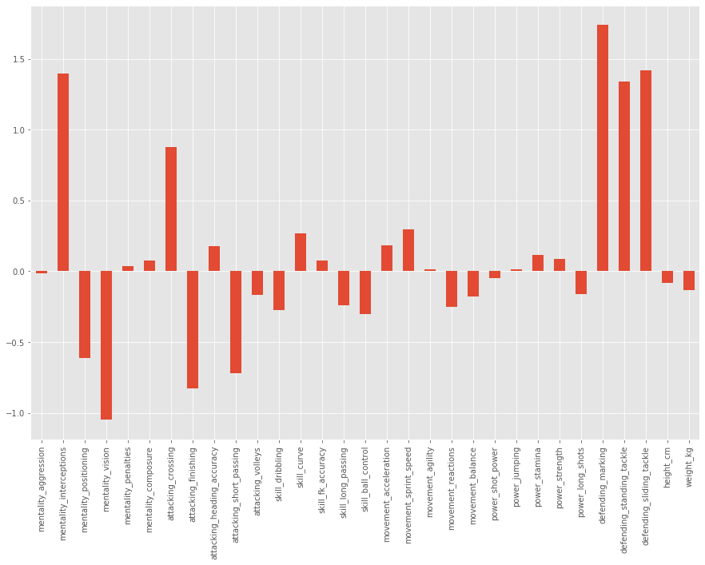

```python
# now let's make a pandas Series with the names and values, and plot them
from matplotlib import pyplot as plt
%matplotlib inline
a =plt.style.use('ggplot')
a =plt.figure(figsize=(15,10))
weights = pd.Series(lr_clf.coef_[0],index=l)
a =weights.plot(kind='bar')
plt.show()
```

```python
df_players_cleaned.groupby(['preferred_position_cat'], as_index=False).mean().groupby('preferred_position_cat')['mentality_interceptions'].mean()

df_players_cleaned.groupby(['preferred_position_cat'], as_index=False).mean().groupby('preferred_position_cat')['attacking_crossing'].mean()

df_players_cleaned.groupby(['preferred_position_cat'], as_index=False).mean().groupby('preferred_position_cat')['mentality_vision'].mean()
```

```
preferred_position_cat
DEF    64.087476
FWD    30.262206
GK     16.536837
MID    47.393756
Name: mentality_interceptions, dtype: float64
```

```
preferred_position_cat
DEF    51.464276
FWD    53.185702
GK     14.120334
MID    59.904007
Name: attacking_crossing, dtype: float64
```

```
preferred_position_cat
DEF    48.921489
FWD    59.517001
GK     38.063851
MID    62.711323
Name: mentality_vision, dtype: float64
```

⏫ Table of Contents